# Parts Simulation Study

Clay Morrow

5/6/2021

Simulation Model:

$$x(t) = \beta_1 u_1 + \beta_2 u_2 + R_1 r_1 + (p_1 u_1 + p_2 u_2 + R_2 r_2) t + (g_1 + R_3 r_3) w_1(t) + \varepsilon(t)$$

- **x(t)**: pixel value at time **t**
- **u**: land classes
- **r**: random spatially correlated effect (unmeasured; 2D sinwave): makes other effects random
- **t**: time point {1, 2, …, **T**}.
- **w**: spatio-temporal predictor variable (tapered AR, fixed nugget and range parameter)
- **beta**, **p**, **g**, **R**: constant throughout sim studies.
- **e(t)**: ARMA(1,1) error:

$$\varepsilon_i(t) = \delta_i(t) + \rho_i \varepsilon_i(t - 1) + \theta_i \varepsilon_i(t-1)$$

- **rho**: constant, except in sim study 4
- **delta**: spatially correlated (tapered, fixed nugget and range parameter)

Simulation Studies:

```r
# spherical tapering function ----
taper.sphr <- function(d, theta){
  ts = ifelse(d > theta, 0, ((1 - d/theta)^2) * (1 + d/(2 * theta)) )
  return(ts)
}
```

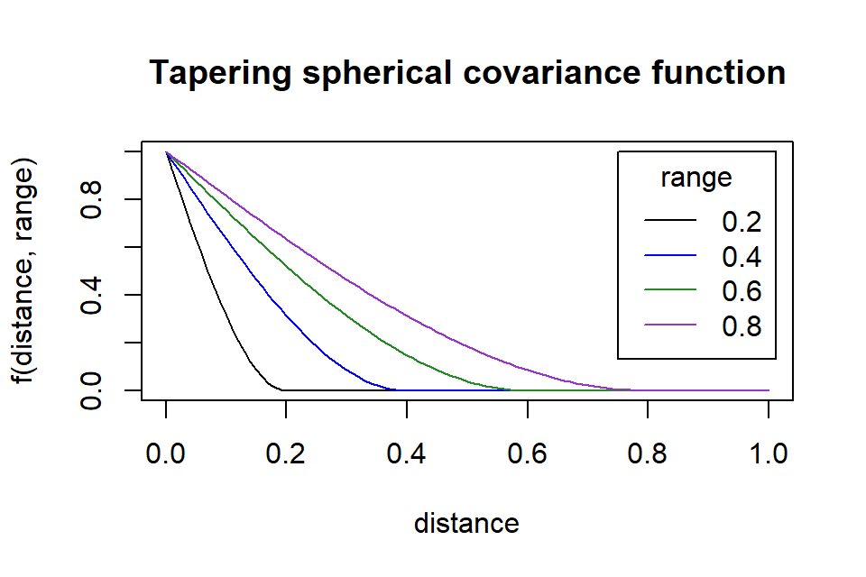

```r
# show taper spherical function with varying thetas
curve(taper.sphr(x, .2), from = 0, to = 1, n = 101, col = "black",
      main = "Tapering spherical covariance function",
      ylab = "f(distance, range)", xlab = "distance")

curve(taper.sphr(x, .4), from = 0, to = 1, n = 101, add = TRUE, col = "blue")
curve(taper.sphr(x, .6), from = 0, to = 1, n = 101, add = TRUE, col = "forestgreen")
curve(taper.sphr(x, .8), from = 0, to = 1, n = 101, add = TRUE, col = "darkorchid3")

legend(x = .75, y = 1,
       legend = c("0.2", "0.4", "0.6", "0.8"),
       col = c("black", "blue", "forestgreen", "darkorchid3"),
       lty = 1,
       title = "range")
```

1. Spatial Only
- T = 1
- varying map sizes: e.g., 10K, 20K, 40K, 80K
- fixed extent of **u**
- test that beta1 = 0 and beta2 = beta1
- plot estimates of beta1 with standard errors
- **p** = **R2** = **g** = **R3** = 0

```r
## Select map dimensions that are divisible by 2, 4, and 8

x <- 100:300
y <- x^2

div2 <- x %% 2 == 0
div4 <- x %% 4 == 0
div8 <- x %% 8 == 0

indx <- which(div2 & div4 & div8)

row.sizes = c(x[indx][which(abs(y[indx] - 10000) == min(abs(y[indx] - 10000)))],
              x[indx][which(abs(y[indx] - 20000) == min(abs(y[indx] - 20000)))],
              x[indx][which(abs(y[indx] - 40000) == min(abs(y[indx] - 40000)))],
              x[indx][which(abs(y[indx] - 80000) == min(abs(y[indx] - 80000)))])

# rm(x, y, div2, div4, div8)
```

```r
# Map parameters ----

# map.rows <- c(100, 150, 200, 280) # map row combinations
# stopifnot(all((map.rows^2) %% 4 == 0)) # check that the square is divisible by 4



map.rows = 16
map.cols = map.rows
npix = map.rows * map.cols

# simulation paramters ----
spat.range = .5 # effective range
nugget = .10
xsd = 0.10

# Map calculations ----
## X, Y coordinates
coords = as.matrix(expand.grid(x = as.double(1:map.cols),
                               y = as.double(1:map.rows)))
## Distance
D.time = system.time(D <- scales::rescale(as.matrix(dist(coords)), to = c(0, 1)))

## Covariance matrix
Sigma <- diag(rep(nugget, npix)) + (1 - nugget) * taper.sphr(D, spat.range)

## Cholesky matrix
# Chol.time = system.time(Cholmat <- base::chol(Sigma))

Chol.time2 = system.time(invchol <- remotePARTS::invert_chol(Sigma, nugget))
```

```r
n.size <- map.cols/4

n.cluster <- 2

land.pattern <- matrix(c(1,2,2,1), ncol = 2, nrow = 2)

landclass <- kronecker(
  kronecker(matrix(1,ncol=n.cluster,nrow=n.cluster), land.pattern),
  matrix(1, nrow=n.size, ncol=n.size))

# ggplot(data.frame(coords, landclass), aes(x = x, y = y, fill = landclass)) +
#   geom_tile(col = "grey50") + theme(legend.position = "none") + labs(title = "landclasses")
```

```r
## 8x8 blocks w/spatial pattern for land cover classes
half.pattern <- matrix(c(rep(c(1,0), each = 4, times = 4), rep(c(0, 1), each = 4, times = 4)), ncol = 8, byrow = TRUE)
quarter.pattern <- matrix(rep(c(rep(c(1,0), each = 2, times = 4), rep(c(0,1), each = 2, times = 4)), times = 2), ncol = 8, byrow = TRUE)
eighth.pattern <-  matrix(rep(c(rep(c(1,0), times = 4), rep(c(0,1), times = 4)), times = 4), ncol = 8, byrow = TRUE)

M.expand <- matrix(1, map.cols/8, map.cols/8)

half.land = kronecker(half.pattern, M.expand)
# image(half.land)
quarter.land = kronecker(quarter.pattern, M.expand)
# image(quarter.land)
eighth.land = kronecker(eighth.pattern, M.expand)
# image(eighth.land)
```

```r
Dr <- t(Sigma)
```

```r
npix = 256
n.time = 1
AR = 0.05
MA = 0.05
xsd = .05
burn.in = 1000
```

```r
# spatially correlated errors
del <- t(scale(Dr %*% rnorm(n = npix, mean = 0, sd = xsd)))
# ARMA errors (ntime columns)
vareps <- t(rbind(apply(X = del, MARGIN = 2,
                  function(e){
                    arima.sim(n = n.time,
                              model = list(ar = AR, ma = MA, innov = e))
                  })))
# dim(vareps)
```

```r
# B1*u1 + B2*u2 + R1*r1 + (p1*u1 + p2*u2 + R2*r2)*t + (g1 + R3*r3)*w1(t) + e(t)
```

```r
if(npix <= 1000){
  ## Check that errors obtained from mvtnorm behave similarly
  del2 <- mvtnorm::rmvnorm(n = n.time, sigma = Sigma, method = "chol")
  vareps2 <- t(rbind(apply(X = del2, MARGIN = 2,
                           function(e){
                             arima.sim(n = n.time,
                                       model = list(ar = AR, ma = MA,
                                                    innov = e))
                           })))

  library(ggplot2)
  # smooth gradient
  ggplot(data.frame(coords, del), aes(x = x, y = y, fill = del)) +
    geom_tile() +
    scale_fill_viridis_c(option = "magma", name = "delta")
  # less smooth, but obvious spatial correlation
  ggplot(data.frame(coords, del), aes(x = x, y = y, fill = del2)) +
    geom_tile() +
    scale_fill_viridis_c(option = "magma", name = "delta2")
  # slightly checkered
  ggplot(data.frame(coords, vareps[,1]), aes(x = x, y = y,
                                             fill = vareps[,1])) +
    geom_tile() +
    scale_fill_viridis_c(option = "magma", name = "varepsilon")
  # even more checkered
  ggplot(data.frame(coords, vareps2[,1]), aes(x = x, y = y,
                                              fill = vareps2[,1])) +
    geom_tile() +
    scale_fill_viridis_c(option = "magma", name = "varepsilon2")

  ## Conclusion, the mvtnorm method produces LESS spatially correlated data
  ## than t(Dr %*% rnorm())
}
```

2. Variable land patch sizes
- T = 30
- map size = 10K
- variable extent of **u**
- test that p1 = 0 and p1 = p2
- **g** = **R3** = 0
3. Effect of spatio-temporal predictor
- T = 30
- map size = 10K
- fixed extent of **u**
- test that g1 = 0
- **p** = **R2** = 0
- variable **R2** if spatial mean of **r2** is 0.
4. Effect on Type I errors (p1 = 0 and p1 = p2)
- variable **w**, all else constant
- variable **r2**, all else constant
- variable **r1**, all else constant
- variable range parameter in **e(t)**, all else constant
- spatially variable **rho** (2D sin wave), all else equal